# Maintain your brain, Primary Cognitive Composite Variable sugbroup by gender

## cogmeanz_full by subgroups of myb_gender

Analyses for the primary composite outcome, three-way interaction between myb_gender, group and time.

```r
# read in functions and data
source("functions.R")

myb_dat <- read.csv(paste0("../../Data/",params$data,".csv")) %>%
  mutate(rc_trial_time = factor(rc_trial_time))
```

## Data summary

```r
myb_dat %>%
  group_by(.dots = lapply(params$predictors, as.symbol)) %>%
  summarize_at(.vars = params$response, .funs = list(Mean = mean, Sd = sd, N_obs = ~length(.)), na.rm=T)
```

```
## # A tibble: 16 x 6
## # Groups:   rc_trial_time, group_type_id [8]
##    rc_trial_time group_type_id myb_gender    Mean    Sd N_obs
##    <fct>                 <int> <chr>        <dbl> <dbl> <int>
##  1 1                         1 Female      0.0128 0.989  1943
##  2 1                         1 Male        0.0303 1.03   1110
##  3 1                         2 Female     -0.0171 0.984  1945
##  4 1                         2 Male       -0.0228 1.02   1106
##  5 10                        1 Female      0.221  0.992  1461
##  6 10                        1 Male        0.241  1.02    820
##  7 10                        2 Female      0.421  1.01   1085
##  8 10                        2 Male        0.323  1.03    527
##  9 11                        1 Female      0.185  0.997  1293
## 10 11                        1 Male        0.245  0.987   721
## 11 11                        2 Female      0.431  1.02    970
## 12 11                        2 Male        0.353  1.02    458
## 13 12                        1 Female      0.111  1.02   1311
## 14 12                        1 Male        0.123  1.03    735
## 15 12                        2 Female      0.369  1.05    956
## 16 12                        2 Male        0.218  1.07    486
```

```r
# if want to run
if(!params$final){

  fitted_mods <- NULL
  fitted_mods$unadj_mod <- lmer(cogmeanz_full ~ rc_trial_time * group_type_id * myb_gender +
                                  (1|id_mask), data=myb_dat)
  fitted_mods$unadj_null <- lmer(cogmeanz_full ~ rc_trial_time * group_type_id + myb_gender +
                                  (1|id_mask), data=myb_dat)
  fitted_mods$adj_mod <- lmer(cogmeanz_full ~ rc_trial_time * group_type_id * myb_gender +
                                rcal_modules_sum + myb_age + cl_edu_yrs + adri_baseline +
                                  (1|id_mask), data=myb_dat)
  fitted_mods$adj_null <- lmer(cogmeanz_full ~ rc_trial_time * group_type_id + myb_gender +
                                rcal_modules_sum + myb_age + cl_edu_yrs + adri_baseline +
                                  (1|id_mask), data=myb_dat)

  save(fitted_mods,file = paste0("../../Results/baseline_sd/",params$response,"_gender"))

} else {
  load(file = paste0("../../Results/baseline_sd/",params$response,"_gender"))
}
```

```r
#plot models

if(!params$final){
  lapply(fitted_mods, plot, form = cond)
}
```

```r
#check summary is okay

if(!params$final){
  lapply(fitted_mods, summary)
}
```

## Results

```r
if(!params$final){


  # unadjusted
  anova_call <- anova(fitted_mods$unadj_null,fitted_mods$unadj_mod)
  likrat <-  data.frame(Chisq = paste0(round(anova_call$Chisq[2],3),"(",
                                       anova_call$Df[2],")"),
                        pvalue = anova_call$`Pr(>Chisq)`[2])




  # two way int EM

  em <- emmeans(fitted_mods$unadj_mod,  ~ rc_trial_time*group_type_id |myb_gender,
                at = list(rc_trial_time = plannedtimes) )
  cont <- contrast(em, interaction = c("consec", "consec"))
  CI <- confint(cont) %>%
    select(myb_gender, asymp.LCL, asymp.UCL)
  Su <- summary(cont)
  cont <- cont %>% as.data.frame() %>%
    select(myb_gender, estimate)


  res_unadj <- left_join(cont, CI)
  res_unadj$zstat = round(Su$z.ratio,3)
  res_unadj$pz = ifelse (Su$p.value < 0.001, "<0.001",paste("= ",round(Su$p.value,3)))
  res_unadj$Chisq = c(likrat$Chisq, NA)
  res_unadj$pvalue = c(likrat$pvalue, NA)

    # adjusted
  anova_call <- anova(fitted_mods$adj_null,fitted_mods$adj_mod)
  likrat <-  data.frame(Chisq = paste0(round(anova_call$Chisq[2],3),"(",
                                       anova_call$Df[2],")"),
                        pvalue = anova_call$`Pr(>Chisq)`[2])
  em <- emmeans(fitted_mods$adj_mod,  ~ rc_trial_time*group_type_id |myb_gender,
                at = list(rc_trial_time = plannedtimes) )
  cont <- contrast(em, interaction = c("consec", "consec"))
  CI <- confint(cont) %>%
    select(myb_gender, asymp.LCL, asymp.UCL)
    Su <- summary(cont)
  cont <- cont %>% as.data.frame() %>%
    select(myb_gender, estimate)


  res_adj <- left_join(cont, CI)
  res_adj$zstat = round(Su$z.ratio,3)
  res_adj$pz = ifelse (Su$p.value < 0.001, "<0.001",paste("= ",round(Su$p.value,3)))

  res_adj$Chisq = c(likrat$Chisq, NA)
  res_adj$pvalue = c(likrat$pvalue, NA)

  res_tab <- rbind(res_unadj, res_adj) %>%
     as.data.frame() %>%
    remove_rownames %>%
    mutate(response = params$response,
           adjusted = c("No","No","Yes","Yes")) %>%
    transmute(response = response, adjusted, myb_gender,
              planned = estimate, asymp.LCL = asymp.LCL, asymp.UCL = asymp.UCL,
              Chisq, p.value = pvalue)


  # save models
  write.csv(res_tab,file = paste0("../../Results/baseline_sd/",params$response,"_gender","_table.csv"), row.names = FALSE)



} else {
  res_tab <- read.csv(file = paste0("../../Results/baseline_sd/",params$response,"_gender","_table.csv"))


}

res <- res_tab %>%
  transmute(response,
            adjusted,
            gender = myb_gender,
            base_3yr_did = round(planned,3),
            LCL = round(asymp.LCL,3),
            UCL = round(asymp.UCL,3),
            Chisq,
            `p.value` = ifelse (`p.value` < 0.001, "<0.001",paste("= ",round(`p.value`,3)))
)

res
```

```
##        response adjusted gender base_3yr_did   LCL   UCL     Chisq  p.value
## 1 cogmeanz_full       No Female        0.218 0.160 0.276 18.426(7)  =  0.01
## 2 cogmeanz_full       No   Male        0.106 0.026 0.186      <NA>     <NA>
## 3 cogmeanz_full      Yes Female        0.214 0.156 0.272 17.585(7) =  0.014
## 4 cogmeanz_full      Yes   Male        0.107 0.028 0.186      <NA>     <NA>
```

```r
evidence_unadj = ifelse(res_tab$p.value[1]<0.05, "evidence", "no evidence")
evidence_adj = ifelse(res_tab$p.value[2]<0.05, "evidence", "no evidence")
```

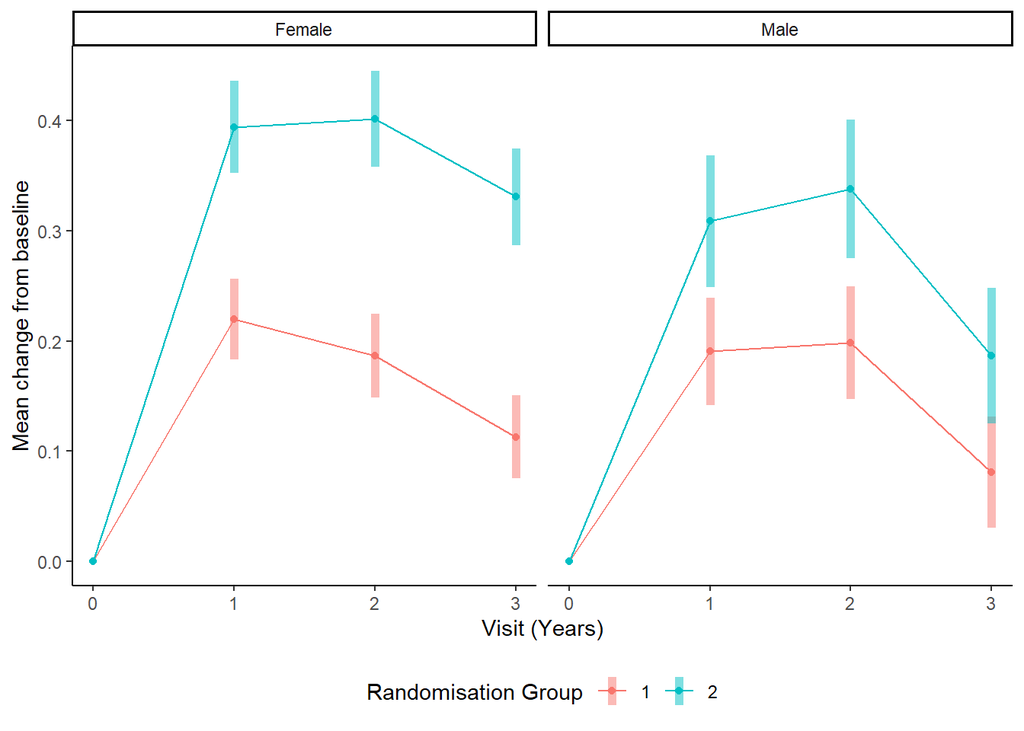

```r
# calculate all ems by time and group
group_time_ems <- emmeans(fitted_mods$unadj_mod,  ~ group_type_id + rc_trial_time| myb_gender)

# contrast to baseline by group
comp_to_baseline <- contrast(group_time_ems, rc_trial_time, "trt.vs.ctrl", by=  c("group_type_id", "myb_gender"))

time_diff <- c(1:3)

to_bl_plot_df <- cbind(summary(comp_to_baseline)[,1:4],
                       confint(comp_to_baseline)[,7:8],
                       `Visit (Years)` = rep(c(1:3), 2))
# add baseline 0
to_bl_plot_df[13:16,] <- NA
to_bl_plot_df$group_type_id[13:16] = c(1,2,1,2)
to_bl_plot_df$estimate[13:16] = 0
to_bl_plot_df$`Visit (Years)`[13:16] = 0
to_bl_plot_df$myb_gender[13:16] = rep(unique(myb_dat$myb_gender), each = 2)

to_bl_plot_df %>%
  ggplot(aes(`Visit (Years)`, estimate,color=factor(group_type_id), group=factor(group_type_id))) +
  geom_point() +
  geom_line()+
  geom_linerange(aes(ymin=asymp.LCL, ymax=asymp.UCL), size=2, alpha=.5) +
  theme_classic() +
  facet_grid(~ myb_gender)+
  ylab("Mean change from baseline") +
  scale_color_discrete(name="Randomisation Group")  +
   theme(legend.position = "bottom")
```

```r
ggsave(file = paste0(params$response,"_",params$data,"_subgroupgender_plot.png"), width = 12, height = 8, units = "cm")



to_bl_plot_df %>%
  transmute(group_type_id, `Visit (Years)`,myb_gender,
         estimate,
         LCL = asymp.LCL, UCL = asymp.UCL) %>%
  arrange(`Visit (Years)`,group_type_id) %>%
write.csv(file = paste0(params$response,"_",params$data,"_subgroupgender_plotdata.csv"), row.names = FALSE)
```

## Result

Covariates included in adjusted models:

- `myb_age`: Age at Baseline
- `cl_edu_yrs`: Years of education
- `adri_baseline`: ADRI at Baseline
- `rcal_modules_sum`: Number of modules person was eligible for

A linear mixed model with a random effect for patient and fixed effects of time point, randomisation group, gender and their interaction was run. An additional analysis including covariates of rcal_modules_sum, myb_age, cl_edu_yrs, adri_baseline was run.

We report p-values for the time point by randomisation group by gender three-way interaction. We report estimates and confidence intervals for difference between randomisation groups of change from baseline to three year follow up (two-way interactions, as in the primary analysis) by gender separately. The units of the effect size are standard deviations at baseline.

The unadjusted difference between randomisation groups of change from baseline to three year follow up was 0.218 ( 95%CI: 0.16- 0.276) baseline standard deviations for females and 0.106 ( 95%CI: 0.026- 0.186) baseline standard deviations for males. We have evidence that the two-way group*time interaction is different between the genders (p= 0.01; this is the 3-way interaction p-value.).

Analysis by Nancy Briggs and Gordana Popovic on 2024-02-14